# HW2-exploration

Author

Danielle Turner

Published

February 2, 2025

### 2B. **Import & wrangle data, then create exploratory data viz**

**Viz #1A: Tree Map of Focus Area Abundance for Funds**

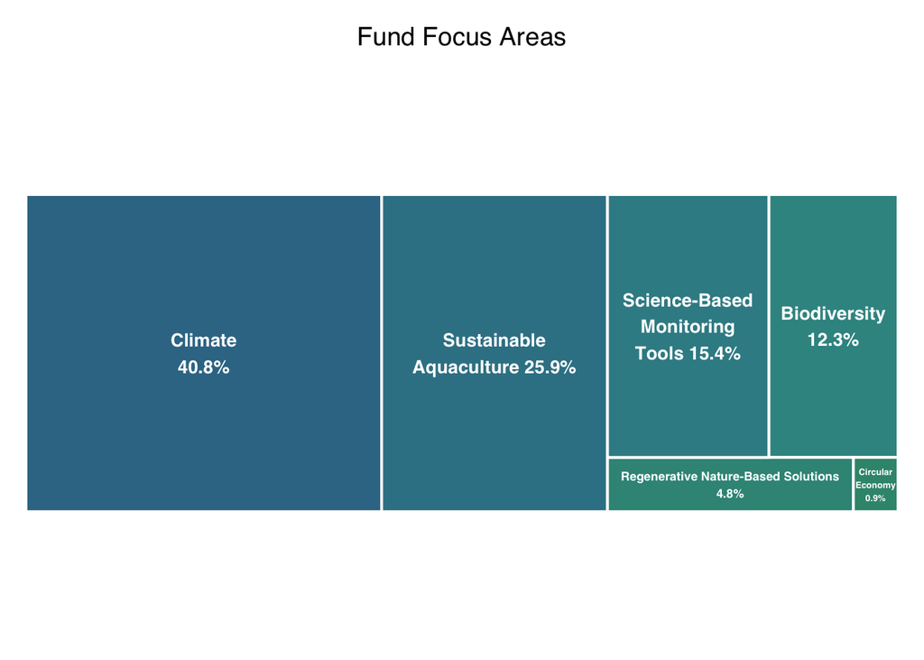

```r
library(here)
library(janitor)
library(tidyverse)
library(dplyr)
library(ggplot2)
library(treemap)

#Read in data
sfohf_companies <- read_csv(here::here("SFOHF_Companies.csv"))

#Wrangle data
treemap_fund_data <- sfohf_companies |>
  clean_names() |>
  select(org_tier_1, focus_area, type) |>
  separate_rows(focus_area, sep = ", ") |>
  group_by(org_tier_1, focus_area, type) |>
  mutate(count = n()) |>
  distinct() |>
  filter(type == "Fund") |>
  ungroup()

# Summarize the count per focus area
treemap_data <- treemap_fund_data |>
  group_by(focus_area) |>
  summarise(count = sum(count)) |>
  arrange(desc(count))

# Calculate total count and percentages
total_count_fund <- sum(treemap_data$count)
treemap_data <- treemap_data |>
  mutate(percentage = (count / total_count_fund) * 100,
         subtext = paste0(round(percentage, 1), "%"),  # to help w label
         label = paste0(focus_area, "\n", subtext))  # label I want on plot

# Make custom colors for each focus area
custom_colors <- c(
  "Climate" = "#387794",
  "Sustainable Aquaculture" = "#388294",
  "Science-Based Monitoring Tools" = "#388C94",
  "Biodiversity" = "#389491",
  "Regenerative Nature-Based Solutions" = "#389486",
  "Circular Economy" = "#38947B")

# Convert focus_area to a factor
treemap_data <- treemap_data |>
  mutate(focus_area = as.factor(focus_area))

# Plot the treemap with labels
treemap_fund <- treemap(treemap_data,
        index = "label",
        vSize = "count",
        vColor = "focus_area",
        type = "categorical",
        palette = unname(custom_colors[levels(treemap_data$focus_area)]),
        title = "Fund Focus Areas",
        fontsize.labels = 10,
        force.print.labels = TRUE,
        aspRatio = 2.75,
        border.col = "white",
        position.legend = "none")
```

**Viz #1B: Tree Map of Focus Area Abundance for Grants**

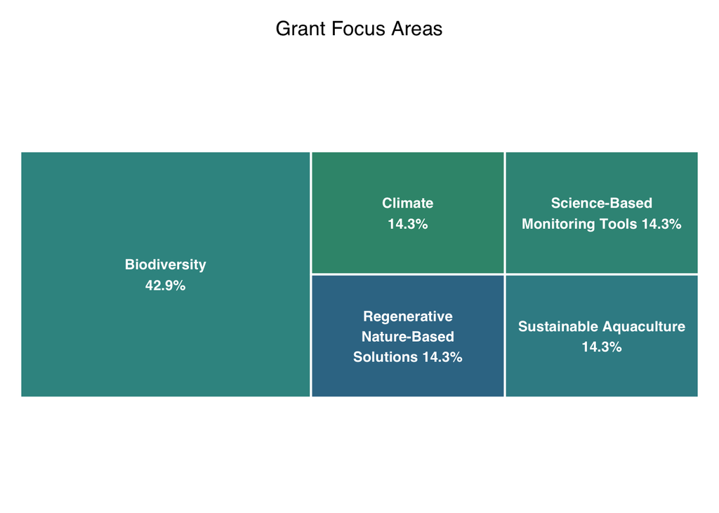

```r
library(here)
library(janitor)
library(tidyverse)
library(dplyr)
library(ggplot2)
library(treemap)

#Wrangle data
treemap_grant_data <- sfohf_companies |>
  clean_names() |>
  select(org_tier_1, focus_area, type) |>
  separate_rows(focus_area, sep = ", ") |>
  group_by(org_tier_1, focus_area, type) |>
  mutate(count = n()) |>
  distinct() |>
  filter(type == "Grant") |>
  ungroup()

# Summarize the count per focus area
treemap_data_grant <- treemap_grant_data |>
  group_by(focus_area) |>
  summarise(count = sum(count)) |>
  arrange(desc(count))

# Calculate total count and percentages
total_count_grant <- sum(treemap_data_grant$count)
treemap_data_grant <- treemap_data_grant |>
  mutate(percentage = (count / total_count_grant) * 100,
         subtext = paste0(round(percentage, 1), "%"),
         label = paste0(focus_area, "\n", subtext))

# Make custom colors for each focus area
custom_colors <- c(
  "Climate" = "#387794",
  "Sustainable Aquaculture" = "#388294",
  "Science-Based Monitoring Tools" = "#388C94",
  "Biodiversity" = "#389491",
  "Regenerative Nature-Based Solutions" = "#389486",
  "Circular Economy" = "#38947B")

# Convert focus_area to a factor
treemap_data_grant <- treemap_data_grant |>
  mutate(focus_area = as.factor(focus_area))

# Plot the treemap with labels
treemap_grant <- treemap(treemap_data_grant,
        index = "label",
        vSize = "count",
        vColor = "focus_area",
        type = "categorical",
        palette = unname(custom_colors[levels(treemap_data$focus_area)]),
        title = "Grant Focus Areas",
        fontsize.labels = 10,
        force.print.labels = TRUE,
        aspRatio = 2.75,
        border.col = "white",
        position.legend = "none")
```

Patchwork does not work with Library(treemap). I would like to stack these two plots vertically in another application like Canva or Google Docs.

**Viz #2: Bar Chart of Focus Areas**

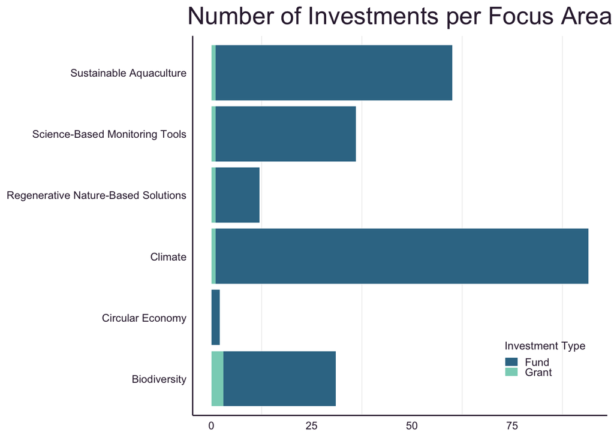

```r
library(here)
library(janitor)
library(tidyverse)
library(dplyr)
library(ggplot2)

#Wrangle Data
foc_area_data <- sfohf_companies |>
  clean_names() |>
  select(org_tier_1, focus_area, type) |>
  separate_rows(focus_area, sep = ", ") |>
  group_by(org_tier_1, focus_area, type) |>
  mutate(count = n()) |>
  distinct()

#Plot bar chart with custom colors and theme
foc_area_data |>
  ggplot(aes(x = focus_area, y = count, fill = type)) +
  geom_col() +
  scale_fill_manual(values = c("Fund" = "#387794", "Grant" = "#89D2C0")) +
  coord_flip() +
  labs(title = "Number of Investments per Focus Area",
       fill = "Investment Type") +
  theme_minimal() +
  theme(
    legend.title = element_text(size = 9,
                                color = "#32213A"),
    axis.title.y = element_blank(),
    axis.title.x = element_blank(),
    legend.position = c(0.85, 0.15),
    legend.key.height = unit(0.25, "cm"),
    legend.key.width = unit(0.4, "cm"),
    legend.text = element_text(color = "#32213A"),
    axis.ticks = element_blank(),
    plot.title = element_text(hjust = 0.5,
                              size = 20,
                              color = "#32213A"),
    axis.line.y = element_line(color = "#32213A"),
    axis.line.x = element_line(color = "#32213A"),
    axis.text = element_text(color = "#32213A"),
    panel.grid.major = element_blank())
```

**Viz #3: Map of Impact Locations (based on Tier 2 Fund HQ locations)**

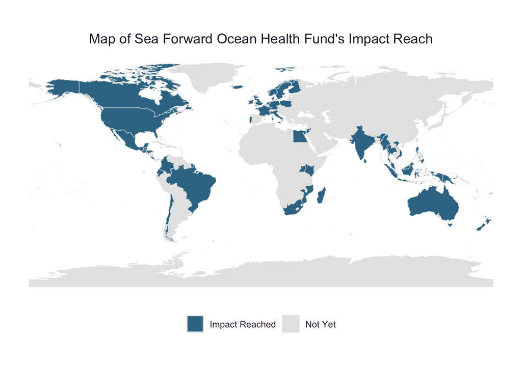

```r
library(here)
library(janitor)
library(tidyverse)
library(dplyr)
library(ggplot2)

#Code adapted from my ESM 206 Homework 1

# Spatial libraries
library(rnaturalearth) # base maps
library(ggspatial) # north arrows and scale
library(ggrepel) #making labels that do not overlap
library(sf) #plotting boundaries
library(rnaturalearthhires)
library(ggplot2)
library(rnaturalearthdata)
library(tidygeocoder)
library(dplyr)

#Get world map data
world <- ne_countries(scale = "medium", returnclass = "sf")

#Define countries to highlight
highlighted_countries <- c("United States", "Scotland", "Kenya", "Israel", "Norway", "Mozambique", "Indonesia", "Thailand", "Finland", "Brazil", "Ireland", "Madagascar", "Zimbabwe, Zambia", "South Africa", "Uganda", "Iceland", "Portugal", "Poland", "Netherlands", "India", "Singapore", "Sweden", "Vietnam", "Canada", "Fiji", "Micronesia", "Papua New Guinea", "Philippines", "Sri Lanka", "Maldives", "Seychelles", "Colombia", "Bahamas", "Guatemala", "Jordan", "Egypt", "Chile", "United Kingdom", "France", "New Zealand", "Puerto Rico", "Australia", "Ecuador", "Germany", "Denmark", "Italy", "Myanmar", "Costa Rica", "Malaysia", "Honduras", "Mexico", "Belize")

world <- world |>
  mutate(highlight = ifelse(name_long %in% highlighted_countries, "Impact Reached", "Not Yet"))

# Plot the map and highlight impact countries
ggplot(data = world) +
  geom_sf(aes(fill = highlight), color = "gray90") +
  scale_fill_manual(values = c("#387794", "gray90")) +
  theme_minimal() +
  ggtitle("Map of Sea Forward Ocean Health Fund's Impact Reach") +
  theme(axis.text = element_blank(),
        axis.title = element_blank(),
        panel.grid = element_blank(),
        legend.position = "bottom",
        legend.title = element_blank()) +
  theme(
    plot.title = element_text(hjust = 0.5,
                              colour = "#32213A"),
     legend.text = element_text(color = "#32213A"))
```

# 2C. Answer Questions

**1. What have you learned about your data? Have any potentially interesting patterns emerged?**

**2. In HW #1, you outlined some questions that you wanted to answer using these data. Have you made any strides towards answering those questions? If yes, how so? If no, what next steps do you need to take (e.g. I need to create X plot type, I still need to track down Y data, I need to restructure existing data so that you can visualize it in Z ways, etc.)?**

I think the above visuals are beginning to answer 2 of the sub questions that I outlines in HW#1:

- Where is impact happening/reaching?
- Which focus areas are we impacting the most?

I think my map is a good way to visualize where impact is happening, but I would like to maybe add some labels to give more context (e.g., how many orgs in each country). My tree maps and bar chart all begin to answer the focus area question… but I originally was hoping to make a doughnut chart for this. I spent a few hours trying to get a doughnut chart to work, but could not figure out how to format the chart properly.

**3. What challenges do you foresee encountering with your data? These can be data wrangling and / or visualization challenges.**

Building off of the previous question, I also attempted making a sankey diagram to answer another question I outlined in HW#1 (which partners contribute to which focus areas?), but after spending a mind-boggling 7 hours on it, I gave up. I couldn’t figure out how to organize my data to make the flow of the diagram work. This is something I’d love to work through if I have more time another week.

Another challenge I may run into is collecting and organizing KPI data that is consistent across several organizations. I have access to impact reports from a handful of organizations, so I will work on organizing KPI data this week and then hopefully will be able to wrangle data and output a nice visual of org-specific impact.